# Tutorial for main functions in medAMM package

Layla Parast

We will go through an example using the main functions in the medAMM package. First, load the package from github with the code below. If you have never installed the package devtools, you will need to do that; see the commented out code below.

```r
# install.packages('devtools')
library(devtools)
devtools::install_github("laylaparast/medAMM")
library(medAMM)
```

The main function is causal.calc.all. This function takes an outcome, an exposure, a set of mediators, and a set of confounders. The outcome and exposure must be binary. The mediators and confounders can be binary and/or continuous. We will use a hypothetical dataset available in the package called datamed. Note that this dataset has a binary outcome, a binary exposure, 3 mediators, and 2 confounders.

```r
data(datamed)
head(datamed)
```

```
##   outcome exposure med1     med2 med3       con1     con2
## 1       1        0    0 23.22575    0 -0.5739536 10.65583
## 2       1        0    0 14.11602    0 -1.1902867 11.88930
## 3       1        0    0 23.29200    1  0.4385522 11.50362
## 4       0        0    0 21.79629    0  0.6600112 11.69007
## 5       1        0    0 18.82470    0 -1.1016343 10.70035
## 6       1        1    0 30.89698    1 -0.2379717 11.85056
```

Now let’s examine mediation. In the code below, I am giving the causal.calc.all function my dataset (argument datas), the names of my confounders, the name of my outcome, the name of my exposure, and the names of the mediators. It is very important that these are given as strings (or a vector of strings) and that these strings map exactly to the variable names in the dataset. The argument conf=FALSE means that I do NOT want confidence intervals. The argument plot=FALSE means I do NOT want a plot.

This function will consider each of the mediators individually and calculate the direct effect, the indirect effect, the total effect, and the resulting proportion of the total effect explained by the mediator. It will then do the same considering all the mediators together.

It will print out “Done with med1”, etc., as it goes to update the user on the status of the analysis. This is especially helpful when you do ask for confidence intervals because it is computationally intensive.

```r
causal.calc.all(datas = datamed, confounders = c("con1", "con2"),
    outcome = "outcome", mainpred = "exposure", mediator.names = c("med1",
        "med2", "med3"), conf = FALSE, plot = FALSE)
```

```
## [1] "Done with  med1"
## [1] "Done with  med2"
## [1] "Done with  med3"
```

```
## $results
##               direct.effect indirect.effect total
## med1          "0.065"       "0.005"         "0.07" "7%"
## med2          "0.037"       "0.033"         "0.07" "47%"
## med3          "0.058"       "0.012"         "0.07" "17%"
## All mediators "0.02"        "0.05"          "0.07" "72%"
##
## $values
## NULL
```

The result is given in the output “results” which is a formatted table with the estimates. The output “values” is only relevant when we are plotting. If plot=FALSE, this will be empty.

In this analysis, 7% of the total effect is mediated by mediator 1, 47% is mediated by mediator 2, 17% is mediated by mediator 3, and 72% is mediated by all 3 mediators together.

Importantly, if you have survey data, you must give a svydesign object to the datas argument and in the function above you must add survey=TRUE.

Now let’s get confidence intervals and a plot. This will take a few minutes.

```
## [1] "Done with  med1"
## [1] "Done with  med2"
## [1] "Done with  med3"
```

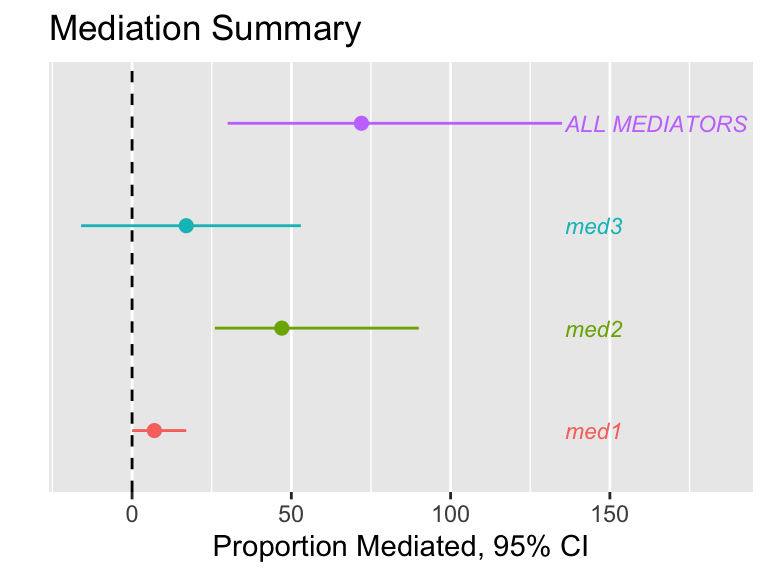

```
## $results
##               direct.effect indirect.effect total
## med1          "0.065"       "0.005"         "0.07" "7% (0%, 17%)"
## med2          "0.037"       "0.033"         "0.07" "47% (26%, 90%)"
## med3          "0.058"       "0.012"         "0.07" "17% (-16%, 53%)"
## All mediators "0.02"        "0.05"          "0.07" "72% (30%, 135%)"
##
## $values
##      prop.mediated 2.5% 97.5%
## [1,]             7    0    17
## [2,]            47   26    90
## [3,]            17  -16    53
## [4,]            72   30   135
```

```r
causal.calc.all(datas = datamed, confounders = c("con1", "con2"),
    outcome = "outcome", mainpred = "exposure", mediator.names = c("med1",
        "med2", "med3"), conf = TRUE, plot = TRUE)
```

Notice that this outputs results (now with confidence intervals) and values, as well as the plot showing the results.

The causal.calc.plot.only function is to be used when you have already run causal.calc.all, but you want to change something in the plot’s display. This function allows you to do that without having to re-run all of the computationally intensive code. You do need to save your causal.calc.all results as an object, here I call it output. I use this function below to make my labels nicer (using plot.labels) and to change the order so that All mediators is at the bottom of the plot.

```
## [1] "Done with  med1"
## [1] "Done with  med2"
## [1] "Done with  med3"
```

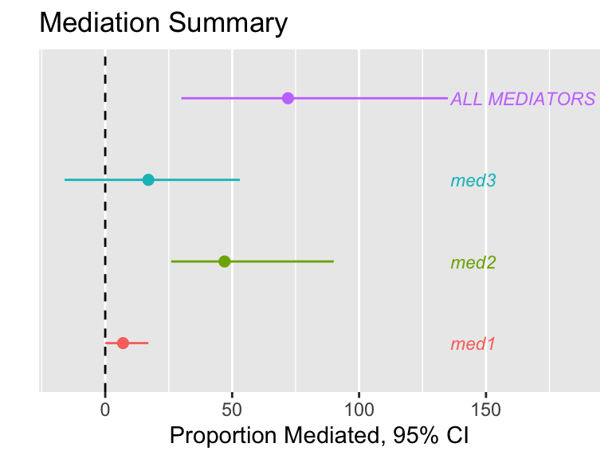

```r
output = causal.calc.all(datas = datamed, confounders = c("con1",
    "con2"), outcome = "outcome", mainpred = "exposure", mediator.names = c("med1",
    "med2", "med3"), plot = TRUE)
```

```r
output
```

```
## $results
##               direct.effect indirect.effect total
## med1          "0.065"       "0.005"         "0.07" "7% (0%, 17%)"
## med2          "0.037"       "0.033"         "0.07" "47% (26%, 90%)"
## med3          "0.058"       "0.012"         "0.07" "17% (-16%, 53%)"
## All mediators "0.02"        "0.05"          "0.07" "72% (30%, 135%)"
##
## $values
##      prop.mediated 2.5% 97.5%
## [1,]             7    0    17
## [2,]            47   26    90
## [3,]            17  -16    53
## [4,]            72   30   135
```

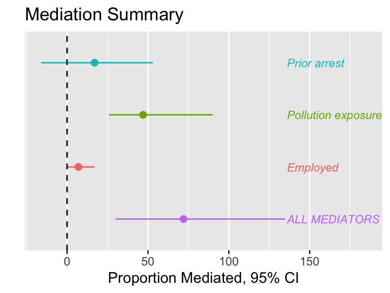

```r
causal.calc.plot.only(output$values, mediator.names = c("med1",
    "med2", "med3"), plot.labels = c("Employed", "Pollution exposure",
    "Prior arrest"), plot.order = c(2, 3, 4, 1))
```